# LGCPs - An example in two dimensions

David Borchers and Finn Lindgren (Comments and edits from JM)

Generated on 2022-06-04

# Introduction

For this vignette we are going to be working with a dataset obtained from the `R` package `spatstat`. We will assume that all objects have been pre-formatted in the necessary spatial data frame format, and we will also assume that the 2D mesh has been pre-defined. We will set up a two-dimensional LGCP to estimate Gorilla abundance.

# Setting things up

Load libraries

```r
library(inlabru)
library(INLA)
library(mgcv)
library(ggplot2)
library(ggpolypath)
```

# Get the data

For the next few practicals we are going to be working with a dataset obtained from the `R` package `spatstat`, which contains the locations of 647 gorilla nests. We load the dataset like this:

```r
data(gorillas, package = "inlabru")
```

This dataset is a list containing a number of `R` objects, including the locations of the nests, the boundary of the survey area and an `INLA` mesh - see `help(gorillas)` for details. Extract the the objects we need from the list, into other objects, so that we don’t have to keep typing ‘`gorillas$`’:

```r
nests <- gorillas$nests
mesh <- gorillas$mesh
boundary <- gorillas$boundary
```

Plot the points (the nests(. (The `ggplot2` function `coord_fixed()` sets the aspect ratio, which defaults to 1.)

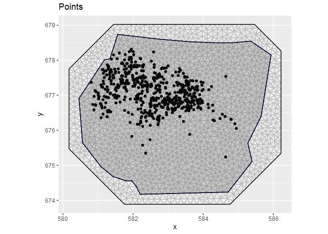

```r
ggplot() +
  gg(mesh) +
  gg(nests) +
  gg(boundary) +
  coord_fixed() +
  ggtitle("Points")
```

# Fitting the model

Fit an LGCP model to the locations of the gorilla nests, predict on the survey region, and produce a plot of the estimated density - which should look like the plot shown below.

Recall that the steps to specifying, fitting and predicting are:

1. Specify a model, comprising (for 2D models) `coordinates` on the left of `~` and an SPDE `+ Intercept(1)` on the right. Please use the SPDE prior specification stated below (*This is probably driven by looking at the scales involved in the above map of the mesh, but why is the quantile so small, at 0.01?*). The ‘coordinates’ component of the model will accept the information contained in the ‘mesh’ object.

```r
matern<-inla.spde2.pcmatern(mesh, prior.range = c(5, 0.01), prior.sigma = c(0.1, 0.01))
mdl<-coordinates~anyName(coordinates, model=matern) + Intercept(1)
```

*Note that, in the definition of the model, the name provided to the smooth can be arbitrary (here, ‘anyName’). I suppose this defines a new function, on the fly, providing the argument ‘coordinates’ and the body ‘model’? In contrast, the component ‘coordinates’ is hard-wired and used as a named argument in the domain definition below, when the ‘lgcp’ model is called.*

2. Call `lgcp( )`, passing it (with 2D models) the model components, the `SpatialPointsDataFrame` containing the observed points and the `SpatialPolygonsDataFrame` defining the survey boundary using the `samplers` argument. Note that the necessary point and polygon data frames are already formatted as spatial data frames in the loaded data set.

```r
fit.spde<-lgcp(mdl, data=nests, samplers=boundary, domain=list(coordinates=mesh))
```

3. Call `predict( )`, passing it the fitted model from 2., locations at which to predict and an appropriate predictor specification. The locations at which to predict should be a `SpatialPixelsDataFrame` covering the mesh obtained by calling `pixels(mesh)`.

```r
pred_Frame<-pixels(mesh, nx = 50, ny = 50, mask = FALSE)
pred_spde<-predict(fit.spde, pred_Frame,~ exp(anyName + Intercept))
```

```r
matern <- inla.spde2.pcmatern(mesh,
  prior.sigma = c(0.1, 0.01),
  prior.range = c(5, 0.01)
)
cmp <- coordinates ~ mySmooth(coordinates,
  model = matern
) +
  Intercept(1)
fit <- lgcp(cmp, nests, samplers = boundary, domain = list(coordinates = mesh))
```

## Predicting intensity

You should get a plot like that below (the command below assumes that the prediction is in an object called `lambda`):

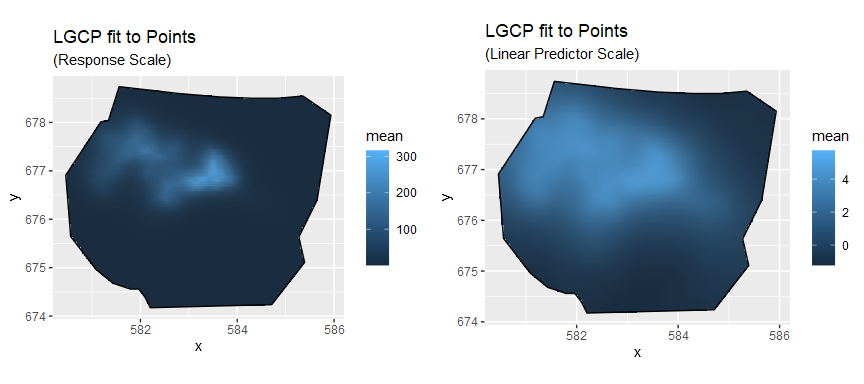

```r
pred <- predict(
  fit,
  pixels(mesh, mask = gorillas$boundary),
  ~ data.frame(
    lambda = exp(mySmooth + Intercept),
    loglambda = mySmooth + Intercept
  )
)
pl1 <- ggplot() +
  gg(pred$lambda) +
  gg(boundary) +
  ggtitle("LGCP fit to Points", subtitle = "(Response Scale)") +
  coord_fixed()
pl2 <- ggplot() +
  gg(pred$loglambda) +
  gg(boundary) +
  ggtitle("LGCP fit to Points", subtitle = "(Linear Predictor Scale)") +
  coord_fixed()
multiplot(pl1, pl2, cols = 2)
```

You can plot the median, lower 95% and upper 95% density surfaces as follows (assuming that the predicted intensity is in object `lambda`).

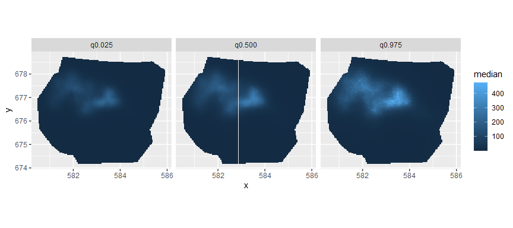

```r
ggplot() +
  gg(cbind(pred$lambda, data.frame(property = "q0.500")), aes(fill = median)) +
  gg(cbind(pred$lambda, data.frame(property = "q0.025")), aes(fill = q0.025)) +
  gg(cbind(pred$lambda, data.frame(property = "q0.975")), aes(fill = q0.975)) +
  coord_equal() +
  facet_wrap(~property)
```

## SPDE parameters

Plot the SPDE parameter and fixed effect parameter posteriors.

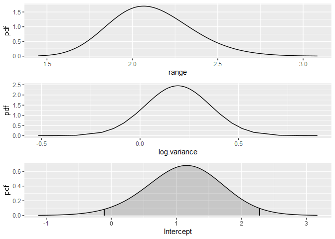

```r
int.plot <- plot(fit, "Intercept")
spde.range <- spde.posterior(fit, "mySmooth", what = "range")
spde.logvar <- spde.posterior(fit, "mySmooth", what = "log.variance")
range.plot <- plot(spde.range)
var.plot <- plot(spde.logvar)
multiplot(range.plot, var.plot, int.plot)
```

Look at the correlation function if you want to:

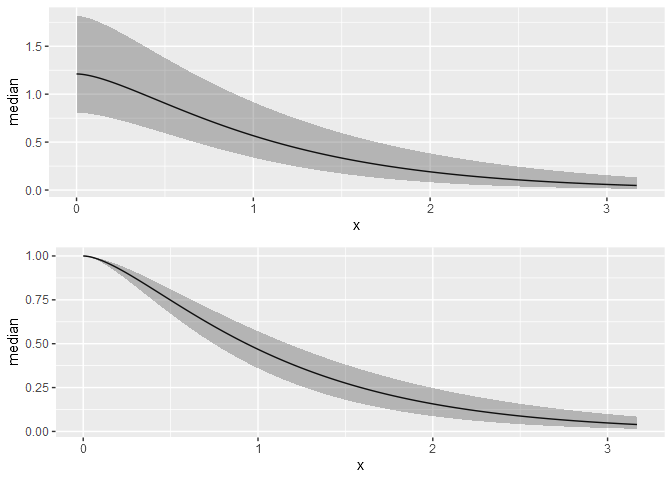

```r
corplot <- plot(spde.posterior(fit, "mySmooth", what = "matern.correlation"))
covplot <- plot(spde.posterior(fit, "mySmooth", what = "matern.covariance"))
multiplot(covplot, corplot)
```

## Estimating Abundance

Finally, estimate abundance using the `predict` function. As a first step we need an estimate for the integrated lambda. The integration `weight` values are contained in the `ipoints` output.

```r
Lambda <- predict(
  fit,
  ipoints(boundary, mesh),
  ~ sum(weight * exp(mySmooth + Intercept))
)
Lambda
```

```
#>       mean       sd   q0.025   median   q0.975     smin     smax         cv
#> 1 648.0693 25.95936 597.0676 649.1341 692.8163 593.4601 715.3806 0.04005646
#>        var
#> 1 673.8885
```

Given some generous interval boundaries (500, 800) for lambda we can estimate the posterior abundance distribution via

```r
Nest <- predict(
  fit, ipoints(boundary, mesh),
  ~ data.frame(
    N = 500:800,
    dpois(500:800,
      lambda = sum(weight * exp(mySmooth + Intercept))
    )
  )
)
```

Get its quantiles via

```r
inla.qmarginal(c(0.025, 0.5, 0.975), marginal = list(x = Nest$N, y = Nest$mean))
```

```
#> [1] 581.5964 649.9127 715.3530
```

… the mean via

```r
inla.emarginal(identity, marginal = list(x = Nest$N, y = Nest$mean))
```

```
#> [1] 649.5823
```

and plot posteriors:

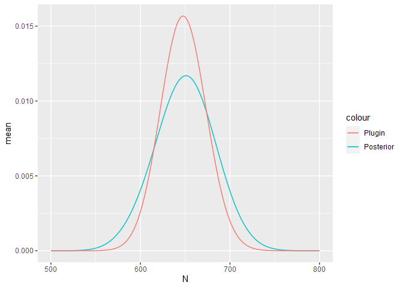

```r
Nest$plugin_estimate <- dpois(Nest$N, lambda = Lambda$mean)
ggplot(data = Nest) +
  geom_line(aes(x = N, y = mean, colour = "Posterior")) +
  geom_line(aes(x = N, y = plugin_estimate, colour = "Plugin"))
```

The true number of nests in 647; the mean and median of the posterior distribution of abundance should be close to this if you have not done anything wrong!